# Classify CCLE to E and M

```r
rm(list=ls())
```

## Summary

This notebook aims to classify CCLE cells to either be E or M, based on known EMT signatures.

```r
library(tidyverse)
```

## 1. Load EMT signatures

There were 3 MSigDB curated up and down signatures I was able to get for hepatocytes (GOTZMANN), mammary (JECHLINGER), and breast (SARRIO) cancer cells.

To get a high confidence list set, I wanted to get the intersection between these datasets for up and down genes. This is to infer the core set of genes used for EMT.

Note: EMTome provides a gene list but does not tell us anything about directionality.

### A. Load upregulated EMT genes

```r
gotzmann_up = read.table('C:/Users/Scott/Desktop/emt_sigs/GOTZMANN_EPITHELIAL_TO_MESENCHYMAL_TRANSITION_UP.txt',
                         skip = 2,
                         header = FALSE,
                         sep ='\n')

jechlinger_up = read.table('C:/Users/Scott/Desktop/emt_sigs/JECHLINGER_EPITHELIAL_TO_MESENCHYMAL_TRANSITION_UP.txt',
                         skip = 2,
                         header = FALSE,
                         sep ='\n')

sarrio_up = read.table('C:/Users/Scott/Desktop/emt_sigs/SARRIO_EPITHELIAL_MESENCHYMAL_TRANSITION_UP.txt',
                         skip = 2,
                         header = FALSE,
                         sep ='\n')
```

### B. Load downregulated EMT genes

```r
gotzmann_dn = read.table('C:/Users/Scott/Desktop/emt_sigs/GOTZMANN_EPITHELIAL_TO_MESENCHYMAL_TRANSITION_DN.txt',
                         skip = 2,
                         header = FALSE,
                         sep ='\n')

jechlinger_dn = read.table('C:/Users/Scott/Desktop/emt_sigs/JECHLINGER_EPITHELIAL_TO_MESENCHYMAL_TRANSITION_DN.txt',
                         skip = 2,
                         header = FALSE,
                         sep ='\n')

sarrio_dn = read.table('C:/Users/Scott/Desktop/emt_sigs/SARRIO_EPITHELIAL_MESENCHYMAL_TRANSITION_DN.txt',
                         skip = 2,
                         header = FALSE,
                         sep ='\n')
```

### C. Load EMT Signature data (PMID30783512)

This gene list was curated from EMTome.

```r
Gordian = read.table('C:/Users/Scott/Desktop/emt_sigs/PMID30783512.txt',
                         skip = 2,
                         header = FALSE,
                         sep ='\n')
```

## 2. Get intersection between gene sets

Now lets get the intersection across datasets.

### A. Intersection Across Up List

```r
emt_up = intersect(gotzmann_up, jechlinger_up, sarrio_up, Gordian)
```

### B. Intersection Across Down List

```r
emt_dn = intersect(gotzmann_dn, jechlinger_dn, sarrio_dn, Gordian)
```

Note that with the additional EMTome geneset, I get the same signatures.

## 3. Load up the CCLE Expression dataset

I’ll load the CCLE Expression dataset. We’ll also assess whether or not expression is statistically significant.

Here is the data README:

```
### CCLE_expression.csv

Pipeline: Expression

RNAseq TPM gene expression data for just protein coding genes using RSEM. Log2 transformed, using a pseudo-count of 1.

- Rows: cell lines (Broad IDs)
- Columns: genes (HGNC symbol and Entrez ID)
```

```r
tpm_data = "D:/Chandrasekaran/Projects/eGEM/Data/RNASeq/CCLE/CCLE_expression.xlsx"
ccle_rnaseq_tpm = readxl::read_excel(tpm_data,
                                     sheet="RSEM Symbol")
```

```r
ach_id = ccle_rnaseq_tpm[, 1]
tmp = ccle_rnaseq_tpm[, -1]

z_tmp = scale(tmp, center=TRUE, scale=TRUE)
p_tmp = 2*pnorm(abs(z_tmp), mean=0, sd=1, lower.tail=FALSE)
```

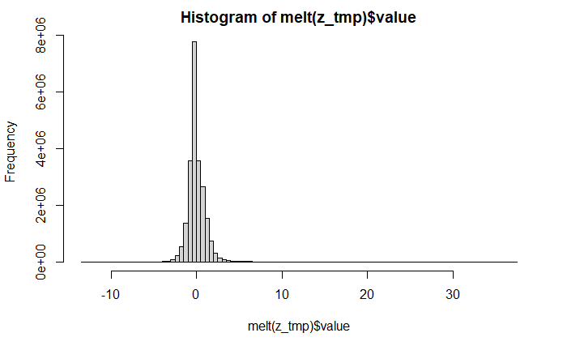

```r
library(reshape)
hist(melt(z_tmp)$value, breaks=100)
```

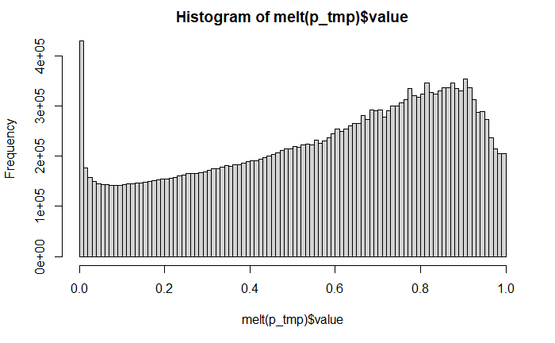

```r
hist(melt(p_tmp)$value, breaks=100)
```

Show whether significant

```r
z_up_idx = z_tmp > 0
z_dn_idx = z_tmp < 0
z_mask = p_tmp < 0.05
```

Mask with significance.

```r
z_up = z_tmp
z_up[!(z_up_idx & z_mask)] = NaN

z_dn = z_tmp
z_dn[!(z_dn_idx & z_mask)] = NaN
```

Mask w/o significance

```r
z_up = z_tmp
z_up[!(z_up_idx)] = NaN

z_dn = z_tmp
z_dn[!(z_dn_idx)] = NaN
```

```r
z_up = data.frame(z_up)
z_up = subset(z_up, select=as.matrix(emt_up))

z_dn = data.frame(z_dn)
z_dn = subset(z_dn, select=as.matrix(emt_dn))
```

## 4. Classify cell lines based on expression

First, get cells that are NSCLC specific and intersect with the CRISPR dataset.

```r
meta_path = "D:/Chandrasekaran/Projects/eGEM/Data/RNASeq/CCLE/sample_info.csv"
meta_data = read.table(meta_path, sep=',', fill=TRUE, header=TRUE)
```

```
EOF within quoted string
```

```r
nsclc_meta = meta_data[meta_data$lineage_subtype=='NSCLC', ]
```

Now map the z_up and z_dn based on the meta data.

```r
tmp = intersect(ach_id$ACH_ID, nsclc_meta$DepMap_ID)
tmp_idx = which(ach_id$ACH_ID %in% nsclc_meta$DepMap_ID)
```

Now let’s get the intersecting data.

Note that when I tried this analysis with significant genes only, the data was pretty sparse. Thus, I ran this analysis with non-significant p-values.

```r
nsclc_achid = ach_id[tmp_idx, ]
nsclc_meta = merge(nsclc_meta, nsclc_achid, by.x="DepMap_ID", by.y="ACH_ID")
nsclc_zup = z_up[tmp_idx, ]
rownames(nsclc_zup) = as.matrix(nsclc_achid)
nsclc_zdn = z_dn[tmp_idx, ]
rownames(nsclc_zdn) = as.matrix(nsclc_achid)
```

```r
cmb = cbind(nsclc_zup, nsclc_zdn)

cmb_idx = (cmb > 0 | cmb < 0)
cmb_idx[is.na(cmb_idx)] = 0
```

Get a sense of the distribution. It’s definitely skewed towards E.

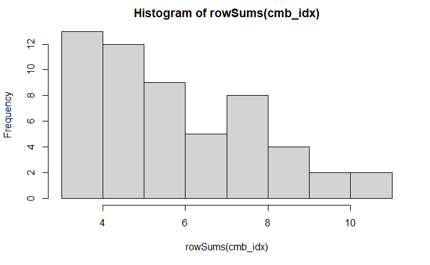

```r
hist(rowSums(cmb_idx))
```

Now let’s label the data.

```r
cmb$numSig = rowSums(!is.na(cmb))
quantile(cmb$numSig)
```

```
  0%  25%  50%  75% 100%
   3    5    6    8   11
```

Subset data based on quantiles

```r
cmb$State = "I"
cmb$State[cmb$numSig <=5] = "E"
cmb$State[cmb$numSig >= 8] = "M"

cmb$state_encoding = NA
cmb$state_encoding[cmb$State == "E"] = 0
cmb$state_encoding[cmb$State == "I"] = 1
cmb$state_encoding[cmb$State == "M"] = 1

tmp = cmb[!is.na(cmb$state_encoding), ]
tmp = tmp[tmp$State != "I", ]
```

Let’s see how this matches with primary/metastatic annotations

```r
col2get = nsclc_meta[, c("DepMap_ID", "primary_or_metastasis")]
tmp = merge(tmp, col2get, by.x=0, by.y="DepMap_ID")

#write_csv(x=cmb, file="D:/Chandrasekaran/Projects/EMT/Analysis/EMT_Clf/emt_annot_nosig.csv")


library(yardstick)
tmp$pm_encoding = 0
tmp$pm_encoding[tmp$primary_or_metastasis == "Metastasis"] = 1

tmp$state_encoding = as.factor(tmp$state_encoding)
tmp$pm_encoding = as.factor(tmp$pm_encoding)



#cmb[cmb$primary_or_metastasis == "Primary", "primary_or_metastasis"] = "E"
#cmb[cmb$primary_or_metastasis == "", "primary_or_metastasis"] = "E"
#cmb[cmb$primary_or_metastasis == NA, "primary_or_metastasis"] = "M"
```

```r
cm = conf_mat(data = tmp, estimate=state_encoding, truth=pm_encoding)
cm
```

```
          Truth
Prediction  0  1
         0 14 11
         1 10  6
```

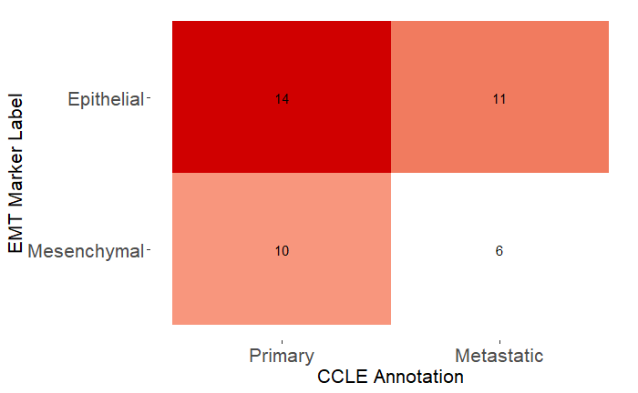

```r
autoplot(cm, type = "heatmap") +
  scale_x_discrete(breaks=c("0","1"),
        labels=c("Primary", "Metastatic")) +
  scale_y_discrete(breaks=c("0","1"),
        labels=c("Epithelial", "Mesenchymal")) +
  xlab("CCLE Annotation") +
  ylab("EMT Marker Label") +
  scale_fill_gradient(low="white", high="#D00000") +
  theme(plot.title = element_text(size=16),
        legend.text=element_text(size=16),
        axis.title.x=element_text(size=16),
        axis.title.y=element_text(size=16),
        axis.text.x=element_text(size=16),
        axis.text.y=element_text(size=16),
        #legend.position=c(0.05, 0.15),
        legend.box="vertical",
        legend.margin=margin(),
        text=element_text(family="sans"))
```

Save the data

```r
write.csv(tmp, "filtered_EMT_Marker_annot.csv")
```

Okay, let’s repeat this with significant genes and just set the threshold to be 0.

```r
z_up = z_tmp
z_up[!(z_up_idx & z_mask)] = NaN

z_dn = z_tmp
z_dn[!(z_dn_idx & z_mask)] = NaN

z_up = data.frame(z_up)
z_up = subset(z_up, select=as.matrix(emt_up))

z_dn = data.frame(z_dn)
z_dn = subset(z_dn, select=as.matrix(emt_dn))

nsclc_zup = z_up[tmp_idx, ]
rownames(nsclc_zup) = as.matrix(nsclc_achid)
nsclc_zdn = z_dn[tmp_idx, ]
rownames(nsclc_zdn) = as.matrix(nsclc_achid)

cmb = cbind(nsclc_zup, nsclc_zdn)

cmb_idx = (cmb > 0 | cmb < 0)
cmb_idx[is.na(cmb_idx)] = 0

cmb$State = "E"
cmb$State[rowSums(cmb_idx) > 0] = "M"
cmb$state_encoding = 0
cmb$state_encoding[cmb$State == "M"] = 1

col2get = nsclc_meta[, c("DepMap_ID", "primary_or_metastasis")]
cmb = merge(cmb, col2get, by.x=0, by.y="DepMap_ID")

cmb$pm_encoding = 0
cmb$pm_encoding[cmb$primary_or_metastasis == "Metastasis"] = 1

cmb$state_encoding = as.factor(cmb$state_encoding)
cmb$pm_encoding = as.factor(cmb$pm_encoding)

cm = conf_mat(data = cmb, estimate=state_encoding, truth=pm_encoding)


autoplot(cm, type = "heatmap") +
  scale_x_discrete(breaks=c("0","1"),
        labels=c("Primary", "Metastatic")) +
  scale_y_discrete(breaks=c("0","1"),
        labels=c("Epithelial", "Mesenchymal")) +
  xlab("CCLE Annotation") +
  ylab("EMT Marker Label (at least 1 sig M marker)") +
  scale_fill_gradient(low="white", high="#D00000")

#write_csv(x=cmb, file="D:/Chandrasekaran/Projects/EMT/Analysis/EMT_Clf/emt_annot_sig.csv")
```

[output not shown]